# Projekt

PałczyńskiMateusz

4 06 2022

# Średnia jakość batonów czekoladowych w zależności od kraju pochodzenia

## Spis treści:

## 1.Ocena jakości batoników przez respondentów.

## 2.Wczytywanie danych

## 3.Wstępna analiza danych

## 4.Postawienie problemu

## 5.Sprawdzenie założeń ANOVA

## 6.Test ANOVA

## 7.Test post-hoc

## 8.Wnioski

## 1. Ocena jakości batoników przez respondentów.

Dane dotyczą ocen batonów z odpowiednich krajów. W ich skład wchodzą: nazwa firmy, wskaźnik referencyjny, rok zebrania danych, procent zawartości kakao, ocena i rodzaj nasion kakao oraz kraju pochodzenia nasion. Batony oceniane są w skali 1 — 5 przez 5 losowych grup około 15 osób. Każda z tych grup dotyczyła oceny w innym kraju.

## 2. Wczytywanie danych

```r
dane1<- read.csv('flavors_of_cacao.csv', head = TRUE)
#w celach badawcych bierzemy miarodajną próbkę z bazy danych
dane <- dane1[c(10:21, 45:59, 76:88,122:136, 448:462), ]
head(dane)
```

```
##    CompanyÂ...Maker.if.known. Specific.Bean.Origin.or.Bar.Name  REF Review.Date
## 10                   A. Morin                          Pablino 1319        2014
## 11                   A. Morin                           Panama 1011        2013
## 12                   A. Morin                       Madagascar 1011        2013
## 13                   A. Morin                           Brazil 1011        2013
## 14                   A. Morin                         Equateur 1011        2013
## 15                   A. Morin                         Colombie 1015        2013
##    Cocoa.Percent Company.Location Rating Bean.Type Broad.Bean.Origin
## 10           70%           France   4.00        Â               Peru
## 11           70%           France   2.75        Â             Panama
## 12           70%           France   3.00   Criollo        Madagascar
## 13           70%           France   3.25        Â             Brazil
## 14           70%           France   3.75        Â            Ecuador
## 15           70%           France   2.75        Â           Colombia
```

```r
lokalizacje <- dane $ Company.Location
oceny <- dane $ Rating
lok_oceny <- factor (lokalizacje,
             levels = c("France", "U.S.A.", "Italy", "U.K.", "Germany"))
```

## 3. Wstępna analiza danych

```r
summary(oceny)
```

```
##    Min. 1st Qu.  Median    Mean 3rd Qu.    Max.
##   1.500   3.000   3.250   3.279   3.750   5.000
```

```r
średnie <- by(oceny ,lokalizacje ,mean)
średnie
```

```
## lokalizacje: France
## [1] 3.375
## ------------------------------------------------------------
## lokalizacje: Germany
## [1] 3.15
## ------------------------------------------------------------
## lokalizacje: Italy
## [1] 3.846154
## ------------------------------------------------------------
## lokalizacje: U.K.
## [1] 3.033333
## ------------------------------------------------------------
## lokalizacje: U.S.A.
## [1] 3.083333
```

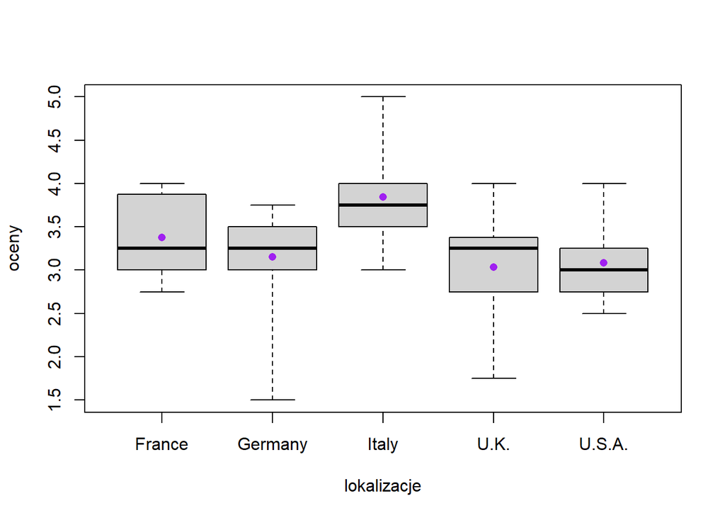

```r
boxplot(oceny ~ lokalizacje, range = 0)
points(średnie, col = "purple", pch = 16)
```

## 4. Postawienie problemu Stawiamy hipotezę, że średnie oceny batonów ze wszystkich krajów są sobie równ przeciw hipotezie alternatywnej - istnieją takie dwie lokazizacje, dla których średnie są różne.

## 5. Sprawdzenie założeń ANOVA

I.Dane te zostały pozyskane w sposób losowy - spełnione. II.Pochodzą z rozkładu normalnego - narysujmy histogramy dla poszczególnych populacji. Naniesiemy na wykresy odpowiadające kolejnym ocenom gęstości.

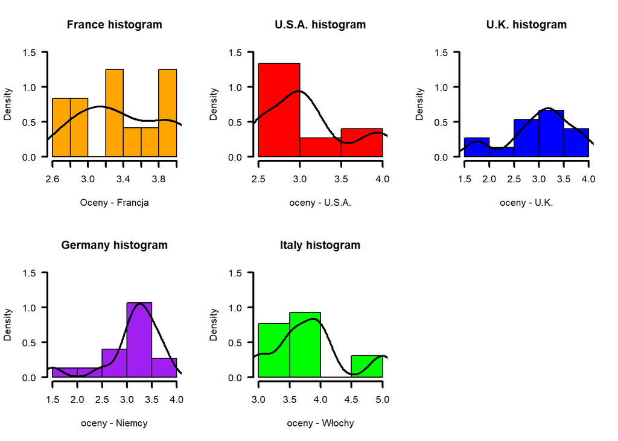

```r
France = subset(dane, subset = (Company.Location == "France"))
U.S.A. = subset(dane, subset = (Company.Location == "U.S.A."))
U.K. = subset(dane, subset = (Company.Location == "U.K."))
Italy = subset(dane, subset = (Company.Location == "Italy"))
Germany = subset(dane, subset = (Company.Location == "Germany"))

par(mfrow=c(2,3))
hist(France[,7],las = 1, main = "France histogram",prob = TRUE,
                      col = "orange1",
                      lwd = 2,
                      xlab = "Oceny - Francja",
                      ylim=c(0,1.5))
lines(density(France[,7]),lwd = 2)

hist(U.S.A.[,7],las = 1, main = "U.S.A. histogram",prob = TRUE,
                      col = "red",
                      lwd = 2,
                      xlab = "oceny - U.S.A.",
                      ylim=c(0,1.5))
lines(density(U.S.A.[,7]),lwd = 2)

hist(U.K.[,7],las = 1, main = "U.K. histogram",prob = TRUE,
                      col = "blue",
                      lwd = 2,
                      xlab = "oceny - U.K.",
                      ylim=c(0,1.5))
lines(density(U.K.[,7]),lwd = 2)

hist(Germany[,7],las = 1, main = "Germany histogram",prob = TRUE,
                      col = "purple",
                      lwd = 2,
                      xlab = "oceny - Niemcy",
                      ylim=c(0,1.5))
lines(density(Germany[,7]),lwd = 2)

hist(Italy[,7],las = 1, main = "Italy histogram",prob = TRUE,
                      col = "green",
                      lwd = 2,
                      xlab = "oceny - Włochy",
                      ylim=c(0,1.5))
lines(density(Italy[,7]),lwd = 2)
```

Oraz sprawdzimy czy próbka pochodzi z rozkładu normalnego za pomocą testu Shapiro-Wilka.

```r
shapiro.test(oceny [lok_oceny == "France"])
```

```
##
##  Shapiro-Wilk normality test
##
## data:  oceny[lok_oceny == "France"]
## W = 0.89475, p-value = 0.1357
```

```r
shapiro.test(oceny [lok_oceny == "U.S.A."])
```

```
##
##  Shapiro-Wilk normality test
##
## data:  oceny[lok_oceny == "U.S.A."]
## W = 0.87719, p-value = 0.04308
```

```r
shapiro.test(oceny [lok_oceny == "Germany"])
```

```
##
##  Shapiro-Wilk normality test
##
## data:  oceny[lok_oceny == "Germany"]
## W = 0.79404, p-value = 0.003086
```

```r
shapiro.test(oceny [lok_oceny == "Italy"])
```

```
##
##  Shapiro-Wilk normality test
##
## data:  oceny[lok_oceny == "Italy"]
## W = 0.88576, p-value = 0.08539
```

```r
shapiro.test(oceny [lok_oceny == "U.K."])
```

```
##
##  Shapiro-Wilk normality test
##
## data:  oceny[lok_oceny == "U.K."]
## W = 0.92209, p-value = 0.2073
```

Dane dla Niemiec i USA nie spełniają naszych założeń o tym, że są z rozkładu normalnego. W celach badawczych przeprowadzimy jednak naszą analizę.

III.Jednorodność wariancji zmiennych losowych.

```r
by(oceny ,lokalizacje , var )
```

```
## lokalizacje: France
## [1] 0.2215909
## ------------------------------------------------------------
## lokalizacje: Germany
## [1] 0.3107143
## ------------------------------------------------------------
## lokalizacje: Italy
## [1] 0.380609
## ------------------------------------------------------------
## lokalizacje: U.K.
## [1] 0.4363095
## ------------------------------------------------------------
## lokalizacje: U.S.A.
## [1] 0.2470238
```

Wariancje poszczególnych wyników z lokalizacji nie odbiegają znacznie od siebie. Jednak dla upewnienia się przeprowadzimy test Barletta.

```r
bartlett.test(oceny ~ lokalizacje, data = dane)
```

```
##
##  Bartlett test of homogeneity of variances
##
## data:  oceny by lokalizacje
## Bartlett's K-squared = 1.9736, df = 4, p-value = 0.7406
```

Test potwierdził nasze przypuszczenie. ## 6. Test ANOVA Możemy teraz przejść do naszego finalnego testu ANOVA

```r
anova (lm(oceny ~ lokalizacje))
```

```
## Analysis of Variance Table
##
## Response: oceny
##             Df  Sum Sq Mean Sq F value   Pr(>F)
## lokalizacje  4  6.0214 1.50535  4.6769 0.002223 **
## Residuals   65 20.9215 0.32187
## ---
## Signif. codes:  0 '***' 0.001 '**' 0.01 '*' 0.05 '.' 0.1 ' ' 1
```

## 7. Test post-hoc

Przeprowadźmy test post-hoc (na poziomie ufności 95%) — Test Tukeya, aby wzbogacić analizę o dodatkowe — dokładniejsze wnioski; średnie ocen z których krajów są parami różne.

```r
TukeyHSD (aov(oceny ~ lok_oceny ), conf.level = 0.95)
```

```
##   Tukey multiple comparisons of means
##     95% family-wise confidence level
##
## Fit: aov(formula = oceny ~ lok_oceny)
##
## $lok_oceny
##                       diff        lwr         upr     p adj
## U.S.A.-France  -0.29166667 -0.9081843  0.32485101 0.6753150
## Italy-France    0.47115385 -0.1660929  1.10840057 0.2435613
## U.K.-France    -0.34166667 -0.9581843  0.27485101 0.5312527
## Germany-France -0.22500000 -0.8415177  0.39151768 0.8433866
## Italy-U.S.A.    0.76282051  0.1596201  1.36602091 0.0063099
## U.K.-U.S.A.    -0.05000000 -0.6312584  0.53125844 0.9992300
## Germany-U.S.A.  0.06666667 -0.5145918  0.64792511 0.9976200
## U.K.-Italy     -0.81282051 -1.4160209 -0.20962012 0.0030572
## Germany-Italy  -0.69615385 -1.2993542 -0.09295345 0.0157230
## Germany-U.K.    0.11666667 -0.4645918  0.69792511 0.9798777
```

## 8. Wnioski

Zauważmy, że średnie są różne jedynie dla relacji: Włochy-U.S.A., Włochy-Wielka Brytania, Włochy-Niemcy. Możemy więc stwierdzić, że średnia jakość batoników we Włoszech jest widocznie lepsza niżeli w Stanach Zjednoczonych, Niemczech czy na Wyspach Brytyjskich. Nie mamy jednak wiedzy by uznać wyższość batoników z Włoch ponad tych pochodzących z Francji.